# Data Visualisation

27 November 2016

## Data Visualisation

### Using the Package `ggplot2`

## The package `ggplot2`

`R` has numerous plotting functions in the base package `graphics`

```r
?plot
?boxplot
?hist
```

**Go to the bottom of each help page and copy a few lines**

## The package `ggplot2`

- `ggplot2` gives much more flexibility and power
- Has unique syntax and approach
- We add layers of plotting information

```r
library(ggplot2)
```

## The package `ggplot2`

### aesthetics

The main function is `ggplot()`

- In this first stage we set the plotting aesthetics using `aes()`
- Defines what is plotted on which axis, what defines the colour/shape etc.

```r
ggplot(data, aes(x = weight, y = height))
```

No data will be plotted. We get the plot area only…

## The package `ggplot2`

### geometry

After defining the plot aesthetics, we add the geometry using various `geom_...()` functions

We tell the first line that "more is to come" by adding a `+` symbol at the end

```r
ggplot(data, aes(x = weight, y = height)) +
  geom_point()
```

## The package `ggplot2`

### geometry

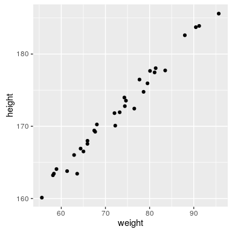

## The package `ggplot2`

### aesthetics

There are numerous aesthetics available for `geom_point()`

```r
?geom_point
```

```r
ggplot(data, aes(x = weight, y = height, colour = transport)) +
  geom_point()
```

```r
ggplot(data, aes(x = weight, y = height, colour = transport, shape = gender)) +
  geom_point()
```

## The package `ggplot2`

### aesthetics

We can put the general aesthetics in `ggplot()`, with the `geom_point()` specific ones in that line

```r
ggplot(data, aes(x = weight, y = height)) +
  geom_point(aes(colour = transport, shape = gender))
```

Aesthetics set outside of `aes()` are general across all points

```r
ggplot(data, aes(x = weight, y = height)) +
  geom_point(aes(colour = transport, shape = gender), size = 4)
```

## The package `ggplot2`

### adding multiple geoms

```r
ggplot(data, aes(x = weight, y = height)) +
  geom_point(aes(colour = transport, shape = gender)) +
  geom_smooth()
```

This defaults to a `loess` fit

```r
ggplot(data, aes(x = weight, y = height)) +
  geom_point(aes(colour = transport, shape = gender)) +
  geom_smooth(method = "lm", formula = y~x, se = FALSE)
```

## The package `ggplot2`

### labels

Axis and legend labels can be added using `labs()`

```r
ggplot(data, aes(x = weight, y = height)) +
  geom_point(aes(colour = transport, shape = gender)) +
  geom_smooth(method = "lm", formula = y~x, se = FALSE) +
  labs(x = "Weight (kg)", y = "Height (cm)",
       shape = "Gender", colour = "Transport")
```

## The package `ggplot2`

### facets

(This is my favourite feature)

```r
ggplot(data, aes(x = weight, y = height)) +
  geom_point(aes(colour = transport, shape = gender)) +
  geom_smooth(method = "lm", formula = y~x, se = FALSE) +
  labs(x = "Weight (kg)", y = "Height (cm)",
       shape = "Gender", colour = "Transport") +
  facet_wrap(~gender)
```

## The package `ggplot2`

### Different geoms

Enter `geom_` in the Console followed by the `tab` key

```r
ggplot(data, aes(x = height, fill = gender)) +
  geom_density(alpha = 0.5)
```

```r
ggplot(data, aes(x = gender, y =height, fill = gender)) +
  geom_boxplot()
```

## The package `ggplot2`

### `geom_bar()`

We can summarise our data, then *pipe* into `ggplot()`

```r
data %>%
  group_by(transport, gender) %>%
  summarise(mn_height = mean(height), sd_height = sd(height)) %>%
  ggplot(aes(x = transport, y = mn_height, fill = transport)) +
  geom_bar(stat = "identity") +
  facet_wrap(~gender) +
  guides(fill =FALSE)
```

NB: `geom_bar()` requires `stat = "identity"`

## The package `ggplot2`

### `geom_errorbar()`

```r
data %>%
  group_by(transport, gender) %>%
  summarise(mn_height = mean(height), sd_height = sd(height)) %>%
  ggplot(aes(x = transport, y = mn_height, fill = transport)) +
  geom_bar(stat = "identity") +
  geom_errorbar(aes(ymin = mn_height - sd_height,
                    ymax = mn_height + sd_height),
                width = 0.6)+
  facet_wrap(~gender) +
  guides(fill =FALSE)
```

## The package `ggplot2`

### facets

**How could we get histograms for both `weight` and `height` using facets?**

- The geom to use is `geom_histogram()`

## The package `ggplot2`

### facets

**How could we get histograms for both `weight` and `height` using facets?**

```r
data %>%
  melt(id.vars = c("gender", "name", "transport")) %>%
  ggplot(aes(x = value, fill = variable)) +
  geom_histogram(bins = 10, colour = "black") +
  facet_wrap(~variable, scales = "free_x") +
  guides(fill = FALSE)
```

## The package `ggplot2`

### facets

```r
data %>%
  melt(id.vars = c("gender", "name", "transport")) %>%
  ggplot(aes(x =gender, y = value, fill = gender)) +
  geom_boxplot() +
  facet_wrap(~variable, scales = "free_y")
```

## A Final Tip

### Using themes

- `ggplot2` utilises themes to control the appearance of the plot
- To remove the grey background add `theme_bw()`

```r
data %>%
  melt(id.vars = c("gender", "name", "transport")) %>%
  ggplot(aes(x =gender, y = value, fill = gender)) +
  geom_boxplot() +
  facet_wrap(~variable, scales = "free_y") +
  theme_bw()
```

[Home](https://uofabioinformaticshub.github.io/Intro_R_Genomics_Dec_2016/)